# Independencia

El segundo requisito que debe cumplir una secuencia de números pseudoaleatorios es la independencia.

Consideraremos pruebas de la forma:

$H_0: u_1, …, u_N$ son independientes $H_a: u_1, …, u_N$ no son independientes

Así que la hipótesis nula es que la secuencia es de números independientes contra la alternativa de que no lo son. Si el valor-p de tal prueba es pequeño, entonces rechazaríamos la hipótesis nula de independencia.

Para diseñar tal prueba, necesitamos idear una manera de cuantificar cuán dependientes son los números en una secuencia entre sí.

Recordemos la idea de correlación: esto te dice cómo dos variables son linealmente dependientes entre sí. Hay una idea similar que extiende la correlación al caso en que se calcula entre una secuencia de números y ella misma, lo que se llama autocorrelación.

Supongamos que tienes dos secuencias de números $u_1, …, u_N$ y $w_1, …, w_N$. Para calcular la correlación mirarías los pares $(u1, w1), (u2, w2), …, (uN, wN)$ y evaluarías cuán relacionados están los números dentro de un par $(ui, wi)$. La correlación, que es un número entre -1 y 1, evalúa cuán relacionadas están las secuencias: cuanto más cercano es el número a uno en valor absoluto, más fuerte es la relación.

Ahora, sin embargo, tenemos solo una secuencia de números $u_1, …, u_N$. Así que, por ejemplo, podríamos mirar los pares $(u_1, u_2), (u_2, u_3), …, (u_{N−1}, u_N)$ que consideran dos números consecutivos y calcular su correlación. De manera similar, podríamos calcular la correlación entre (u1, u1+k), (u2, u2+k), …, (uN−k, uN) entre cada número en la secuencia y el que está k-posiciones adelante. Esto es lo que llamamos autocorrelación de desfase k.

Si las autocorrelaciones de varios desfases están cerca de cero, esto indica que los datos son independientes. Si, por otro lado, la autocorrelación en algunos desfases es grande, entonces hay una indicación de dependencia en la secuencia de números aleatorios.

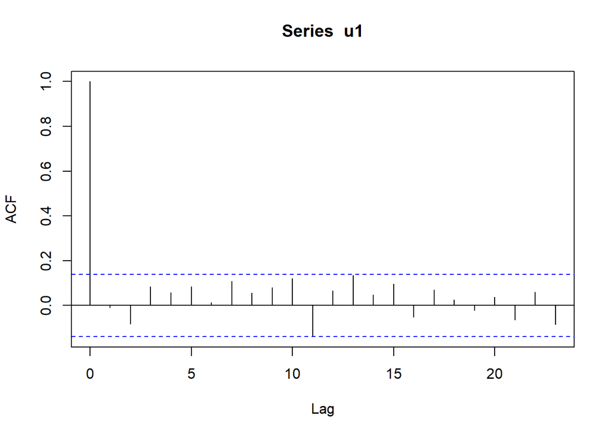

```r
set.seed(2021)
u1 <- runif(200)
acf(u1)
```